# Olympics Analysis

Joey Schafer, Jaden Stetler, Clay Wahlstrom

## R Markdown

First, we imported the Olympic data into our R environment.

We then found a subset of the data where only athletes who medalled were included.

In the source datafile, only the host city was listed. We then created a function which would map these cities to the NOC codes for the host country, in order to see if there is a home field advantage.

We then decided to look at whether or not having “home field advantage” - in other words, being from the host country, increased the likelihood of taking home a medal. We wanted to use a subset of the data where the country had hosted the Olympics multiple times to attempt to avoid an outlier skewing our analysis, as well as a country who had won a relatively significant number of medals. This led us to primarily consider US Olympic medal data. This first chart shows how often, in totality, the US wins an Olympic medal.

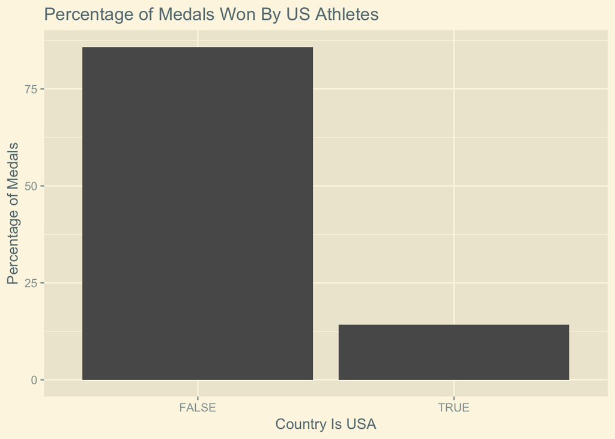

We then wanted to look and see if the relative share of medals won by US athletes was significantly increased if the United States was hosting the games.

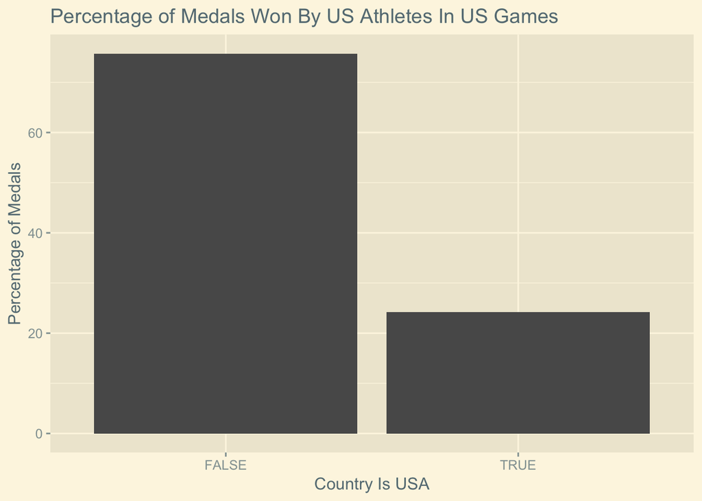

However, often, countries prioritize the gold medal above all else, so a complete study of this phenomenon would be remiss if it did not include gold medals as their own specific category. Ours will not neglect this specific case - this next chart is of the percentage of gold medals across all Olympic games won by US athletes.

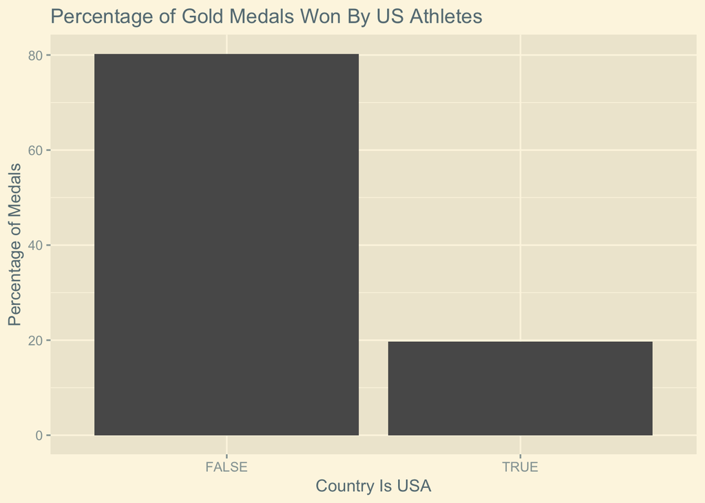

Finally, this chart shows the relative share of gold medals won by the US in games hosted by the US.

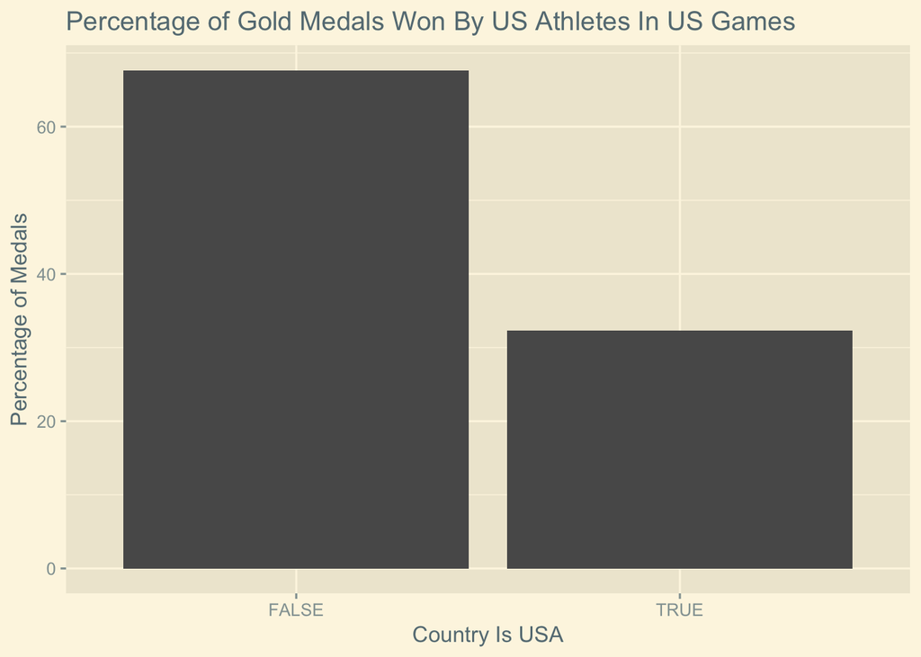

As is clearly evident from the graphs, the US performs substantially better, in terms of both total medals and gold medals, when the US is the host nation. US Athletes win approximately 13% of all medals, but in US games this is increased to approximately 25%. Additionally, US athletes win around 20% of all gold medals, but when the US is at home this is increased to around 32%. Therefore, for at least the US team, having a “home” Olympics constitutes a significant advantage.